# Análise de regressão linear

**Criação do Conjunto de Dados**

```r
# Define a semente para reprodutibilidade para garantir que os resultados de funções que dependem de aleatoriedade sejam sempre os mesmos quando o código for executado novamente.
set.seed(123)

# Número de observações
n <- 30

# -Criação das variáveis:

# - sqft: área em pés quadrados (entre 800 e 3000)
# - bedrooms: número de quartos (entre 2 e 5)
# - age: idade da casa (entre 0 e 50 anos)
sqft <- round(runif(n, 800, 3000))
bedrooms <- sample(2:5, n, replace = TRUE)
age <- round(runif(n, 0, 50))

# Criação do price como uma função linear de sqft, bedrooms e age, com ruído
price <- round(200 * sqft + 30000 * bedrooms - 1000 * age + rnorm(n, mean = 0, sd = 30000))


# Criação do data frame
dados_habitacao <- data.frame(ID = 1:n,
                              sqft = sqft,
                              bedrooms = bedrooms,
                              age = age,
                              price = price)
```

## 0.1 1. Regressão Linear Simples

Nesta seção, modelizamos a relação entre o price da habitação em USD (price) e a área em pés quadrados (sqft).

**Análise Exploratória dos Dados**

```r
# Estatísticas descritivas para sqft e price
summary(dados_habitacao$sqft)
```

```
   Min. 1st Qu.  Median    Mean 3rd Qu.    Max.
    893    1566    2084    2059    2691    2987
```

```r
summary(dados_habitacao$price)
```

```
   Min. 1st Qu.  Median    Mean 3rd Qu.    Max.
 225600  372254  478972  484120  619322  708494
```

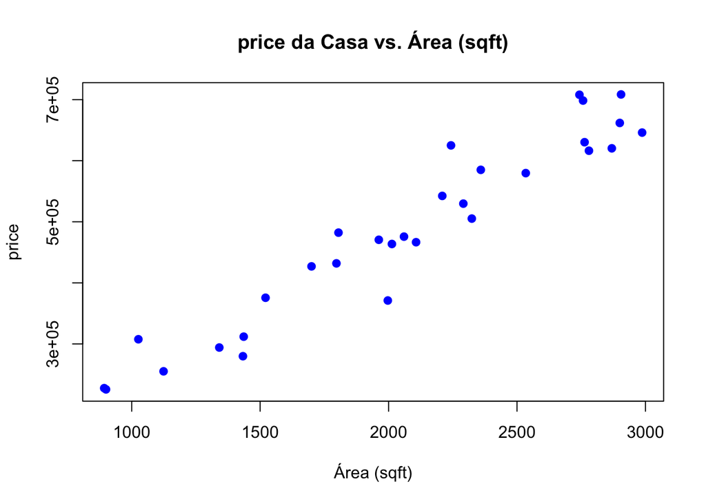

```r
# Gráfico de dispersão: price vs. Área
plot(dados_habitacao$sqft, dados_habitacao$price,
     main = "price da Casa vs. Área (sqft)",
     xlab = "Área (sqft)",
     ylab = "price",
     pch = 19, col = "blue")
```

Modelo de Regressão Linear Simples Agora, ajustamos o modelo utilizando a função lm():

# 1 Ajusta o modelo de regressão linear simples

```r
modelo_simples <- lm(price ~ sqft, data = dados_habitacao)
# função lm()
# Variável dependente (resposta): price
# Variável independente (preditor): sqft

# Exibe o resumo do modelo
summary(modelo_simples)
```

```
Call:
lm(formula = price ~ sqft, data = dados_habitacao)

Residuals:
   Min     1Q Median     3Q    Max
-98902 -28129  -7679  24344  99427

Coefficients:
            Estimate Std. Error t value Pr(>|t|)
(Intercept)  18272.0    26925.4   0.679    0.503
sqft           226.2       12.5  18.094   <2e-16 ***
---
Signif. codes:  0 '***' 0.001 '**' 0.01 '*' 0.05 '.' 0.1 ' ' 1

Residual standard error: 43160 on 28 degrees of freedom
Multiple R-squared:  0.9212,    Adjusted R-squared:  0.9184
F-statistic: 327.4 on 1 and 28 DF,  p-value: < 2.2e-16
```

**Output explicado:**

**Resíduos** São as diferenças entre os valores reais e os valores preditos pelo modelo.

Estatísticas importantes:

Min: -98,902 → Residual mais negativo (sobrestimação do price) 1º Quartil (1Q): -28,129 → 25% dos resíduos são menores que esse valor. Mediana: -7,679 → Mediana dos resíduos, próxima de zero, o que indica que o modelo pode estar bem balanceado. 3º Quartil (3Q): 24,344 → 75% dos resíduos são menores que esse valor. Máximo: 99,427 → Residual mais positivo (subestimação do price).

Interpretação: O modelo tem desvios grandes entre valores preditos e reais.

**Coeficientes da Regressão**

Intercept: 18,272, representa o price esperado de uma casa quando sqft=0 Não é significativo (𝑝= 0.503, logo não é seguro avaliar esta relação isoladamente)

Coeficiente de sqft: 226.2, por cada unidade de aumento (1 sqft) o price esperado aumenta em $226.2, p < 0.001

**Qualidade do Ajuste do Modelo** Erro Padrão dos Resíduos: média dos erros de previsão. Quanto menor, melhor. R2 (Coeficiente de Determinação): 0.9212. 92.12% da variação nos prices das casas é explicada pela área. Indica um ajuste muito bom do modelo. R2 Ajustado (usamos sempre este): 0.9184. Estatística F: 327.4, p < 2.2e-16. Indica que o modelo é significativo e explica a variabilidade dos dados.(Não sendo significativo, não podemos devemos o modelo para explicação/previsão.)

Visualizando a linha de regressão ajustada:

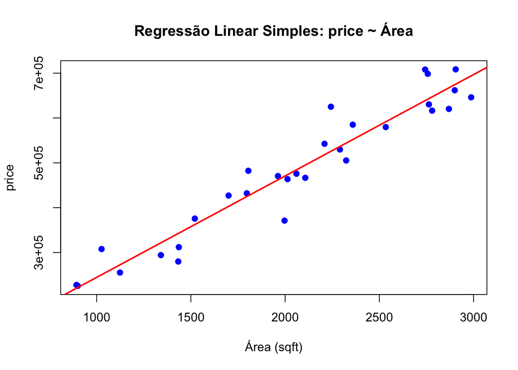

```r
plot(dados_habitacao$sqft, dados_habitacao$price,
     main = "Regressão Linear Simples: price ~ Área",
     xlab = "Área (sqft)",
     ylab = "price",
     pch = 19, col = "blue")
abline(modelo_simples, col = "red", lwd = 2)
```

**Verificação das Condições de Aplicabilidade**

**Relação Linear** - Gráfico de dispersão com recta de regressão

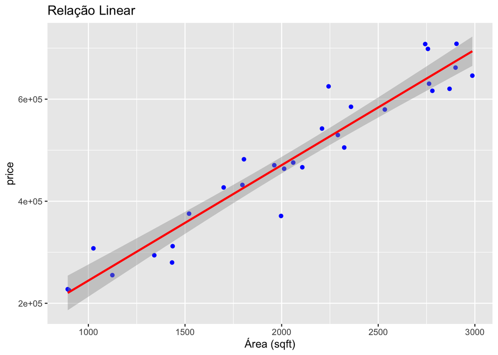

```r
library(ggplot2)
ggplot(data = dados_habitacao, aes(x = sqft, y = price))+
  geom_point(color = "blue")+
  geom_smooth(method = "lm", color = "red") +
  labs(
    title = "Relação Linear",
    x = "Área (sqft)",
    y = "price"
  )
```

**Normalidade dos Resíduos** - Histograma e Teste de Shapiro-Wilk

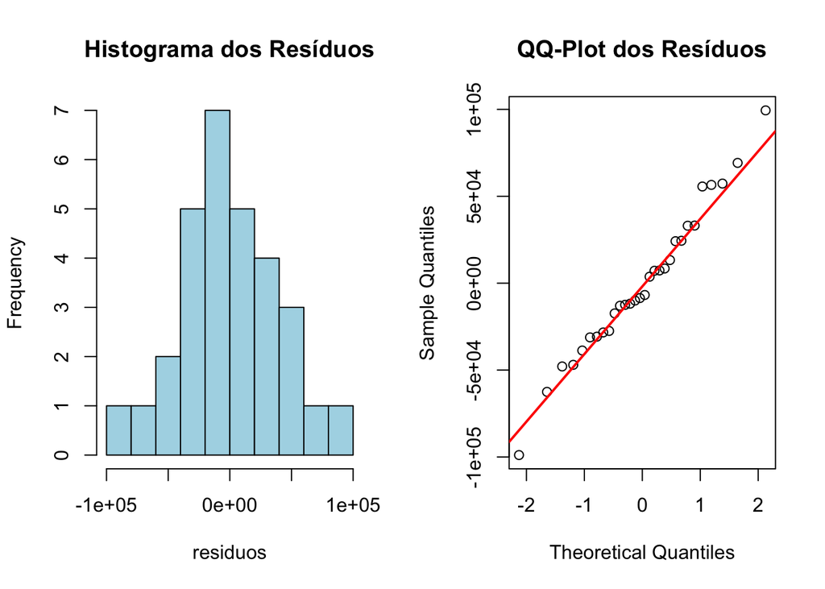

```r
residuos <- residuals(modelo_simples)

par(mfrow = c(1, 2))  # Ajustar layout gráfico para visualizar dois gráficos lado a lado
hist(residuos, main = "Histograma dos Resíduos", col = "lightblue", breaks = 10)
qqnorm(residuos, main = "QQ-Plot dos Resíduos")
qqline(residuos, col = "red", lwd = 2)
```

```r
shapiro.test(residuos)  # Teste de normalidade dos resíduos
```

```
    Shapiro-Wilk normality test

data:  residuos
W = 0.98514, p-value = 0.9396
```

```r
par(mfrow = c(1, 1))  # Retornar ao layout gráfico normal
```

**Variabilidade Constante (Homocedasticidade)** - Gráfico de resíduos vs. valores ajustados

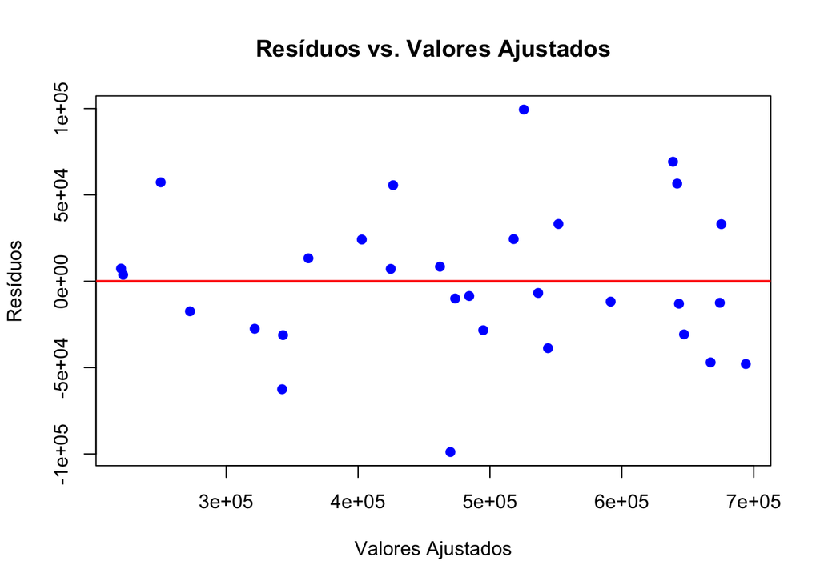

```r
plot(fitted(modelo_simples), residuos,
     main = "Resíduos vs. Valores Ajustados",
     xlab = "Valores Ajustados", ylab = "Resíduos",
     pch = 19, col = "blue")
abline(h = 0, col = "red", lwd = 2)
```

```r
# Teste de Breusch-Pagan para verificar homocedasticidade
library(lmtest)
bptest(modelo_simples)
```

```
    studentized Breusch-Pagan test

data:  modelo_simples
BP = 0.32375, df = 1, p-value = 0.5694
```

**Detecção de Outliers Extremos** - Boxplot e Influência Leverage

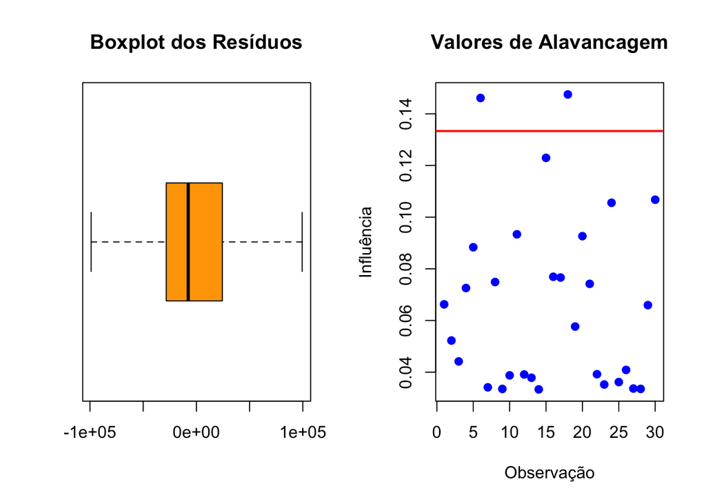

```r
par(mfrow = c(1, 2))
boxplot(residuos, main = "Boxplot dos Resíduos", col = "orange", horizontal = TRUE)
plot(hatvalues(modelo_simples), main = "Valores de Alavancagem",
     ylab = "Influência", xlab = "Observação", pch = 19, col = "blue")
abline(h = 2 * mean(hatvalues(modelo_simples)), col = "red", lwd = 2)
```

```r
par(mfrow = c(1, 1))  # Retornar ao layout normal
```

## 1.1 2. Regressão Linear Múltipla

```r
library(MASS)
```

Ampliamos nossa análise incorporando mais preditores: sqft, bedrooms, age

Análise Exploratória dos Dados

# 2 Estatísticas descritivas para os preditores e price

```r
summary(dados_habitacao[, c("sqft", "bedrooms", "age", "price")])
```

```
      sqft         bedrooms        age            price
 Min.   : 893   Min.   :2.0   Min.   : 0.00   Min.   :225600
 1st Qu.:1566   1st Qu.:2.0   1st Qu.:15.00   1st Qu.:372254
 Median :2084   Median :3.0   Median :23.00   Median :478972
 Mean   :2059   Mean   :3.3   Mean   :25.70   Mean   :484120
 3rd Qu.:2691   3rd Qu.:4.0   3rd Qu.:38.75   3rd Qu.:619322
 Max.   :2987   Max.   :5.0   Max.   :49.00   Max.   :708494
```

# 3 Matriz de gráficos para visualizar as relações

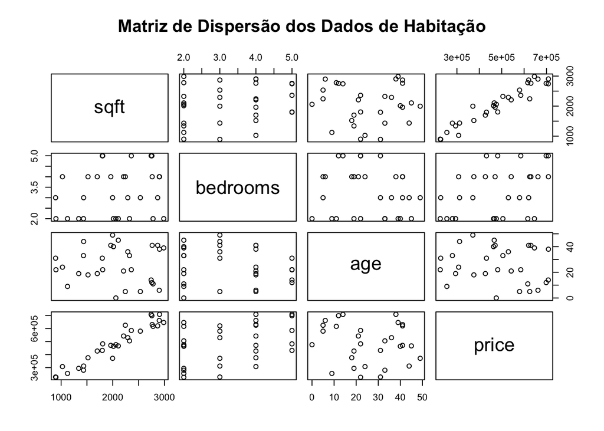

```r
pairs(dados_habitacao[, c("sqft", "bedrooms", "age", "price")],
      main = "Matriz de Dispersão dos Dados de Habitação")
```

# 4 Ajusta o modelo de regressão múltipla: price ~ sqft + bedrooms + age

```r
#Método Enter (Regressão Completa)
modelo_multiplo <- lm(price ~ sqft + bedrooms + age, data = dados_habitacao)
summary(modelo_multiplo)  # Mostra todos os coeficientes
```

```
Call:
lm(formula = price ~ sqft + bedrooms + age, data = dados_habitacao)

Residuals:
   Min     1Q Median     3Q    Max
-65488 -12330   -854  13413  60085

Coefficients:
              Estimate Std. Error t value Pr(>|t|)
(Intercept) -15415.637  23359.727  -0.660  0.51511
sqft           216.391      8.044  26.902  < 2e-16 ***
bedrooms     25187.230   4659.675   5.405 1.16e-05 ***
age          -1136.034    363.047  -3.129  0.00429 **
---
Signif. codes:  0 '***' 0.001 '**' 0.01 '*' 0.05 '.' 0.1 ' ' 1

Residual standard error: 27090 on 26 degrees of freedom
Multiple R-squared:  0.9712,    Adjusted R-squared:  0.9679
F-statistic: 292.1 on 3 and 26 DF,  p-value: < 2.2e-16
```

```r
#Regressão Stepwise (Método Passo-a-Passo)
modelo_stepwise <- step(lm(price ~ 1, data = dados_habitacao),  # Começa sem variáveis
scope = ~ sqft + bedrooms + age,  # Define as variáveis candidatas
direction = "both")  # Alterna entre forward e backward
```

```
Start:  AIC=716.52
price ~ 1

           Df  Sum of Sq        RSS    AIC
+ sqft      1 6.0977e+11 5.2153e+10 642.29
+ bedrooms  1 1.0745e+11 5.5447e+11 713.20
<none>                   6.6192e+11 716.52
+ age       1 1.3122e+10 6.4880e+11 717.92

Step:  AIC=642.29
price ~ sqft

           Df  Sum of Sq        RSS    AIC
+ bedrooms  1 2.5895e+10 2.6258e+10 623.70
+ age       1 1.1643e+10 4.0510e+10 636.71
<none>                   5.2153e+10 642.29
- sqft      1 6.0977e+11 6.6192e+11 716.52

Step:  AIC=623.7
price ~ sqft + bedrooms

           Df  Sum of Sq        RSS    AIC
+ age       1 7.1835e+09 1.9074e+10 616.11
<none>                   2.6258e+10 623.70
- bedrooms  1 2.5895e+10 5.2153e+10 642.29
- sqft      1 5.2822e+11 5.5447e+11 713.20

Step:  AIC=616.11
price ~ sqft + bedrooms + age

           Df  Sum of Sq        RSS    AIC
<none>                   1.9074e+10 616.11
- age       1 7.1835e+09 2.6258e+10 623.70
- bedrooms  1 2.1435e+10 4.0510e+10 636.71
- sqft      1 5.3094e+11 5.5002e+11 714.96
```

```r
summary(modelo_stepwise)
```

```
Call:
lm(formula = price ~ sqft + bedrooms + age, data = dados_habitacao)

Residuals:
   Min     1Q Median     3Q    Max
-65488 -12330   -854  13413  60085

Coefficients:
              Estimate Std. Error t value Pr(>|t|)
(Intercept) -15415.637  23359.727  -0.660  0.51511
sqft           216.391      8.044  26.902  < 2e-16 ***
bedrooms     25187.230   4659.675   5.405 1.16e-05 ***
age          -1136.034    363.047  -3.129  0.00429 **
---
Signif. codes:  0 '***' 0.001 '**' 0.01 '*' 0.05 '.' 0.1 ' ' 1

Residual standard error: 27090 on 26 degrees of freedom
Multiple R-squared:  0.9712,    Adjusted R-squared:  0.9679
F-statistic: 292.1 on 3 and 26 DF,  p-value: < 2.2e-16
```

**Verificação dos Pressupostos**

**Linearidade da relação entre as variáveis**

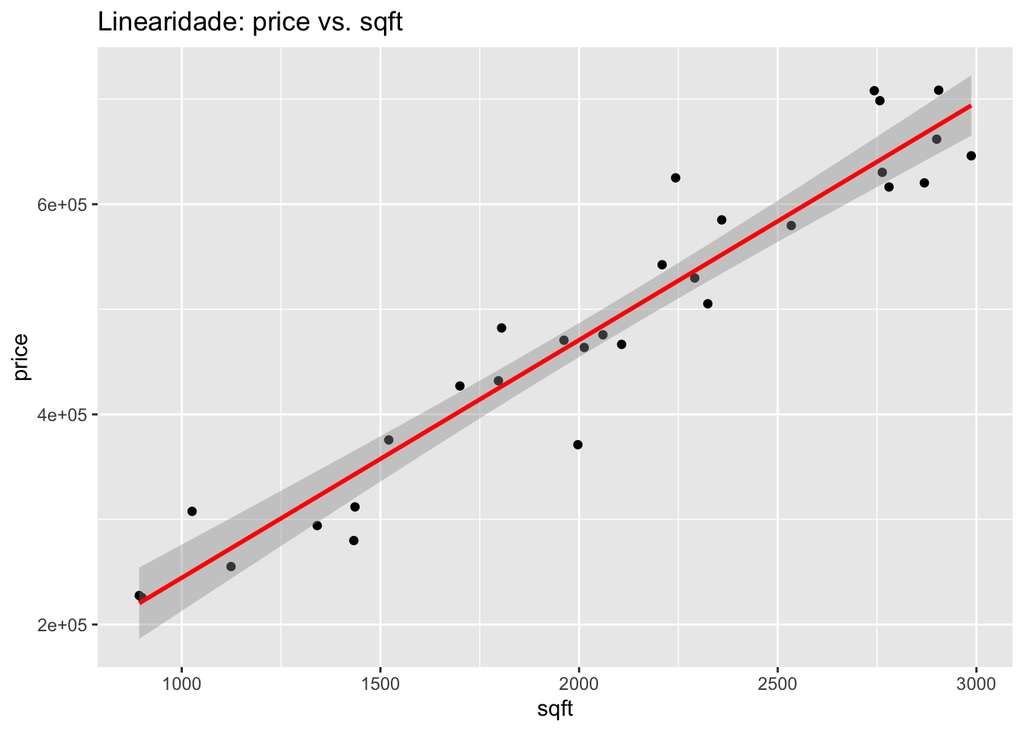

```r
library(ggplot2)

ggplot(dados_habitacao, aes(x = sqft, y = price)) +
  geom_point() +
  geom_smooth(method = "lm", col = "red") +
  labs(title = "Linearidade: price vs. sqft")
```

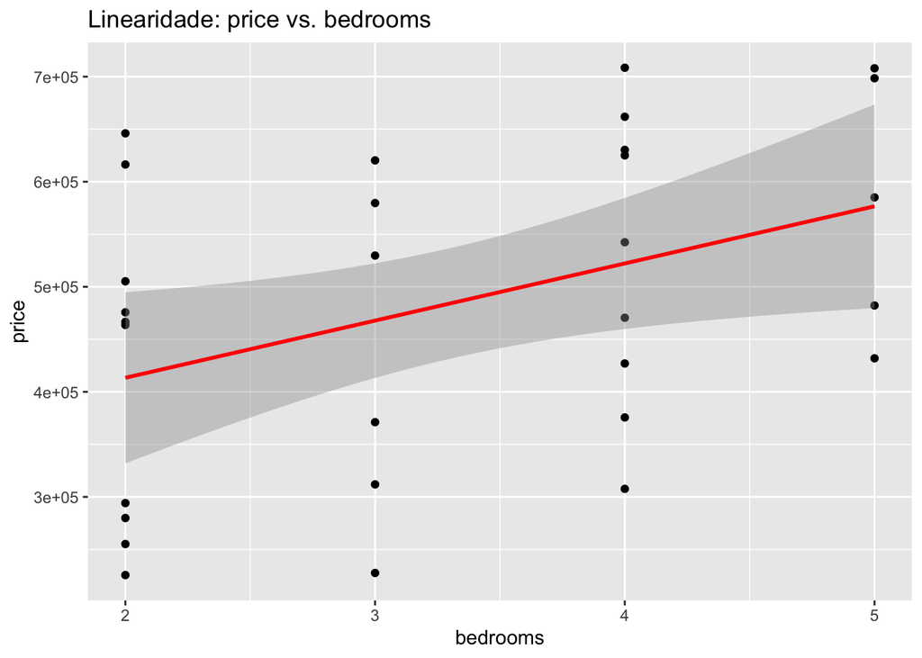

```r
ggplot(dados_habitacao, aes(x = bedrooms, y = price)) +
  geom_point() +
  geom_smooth(method = "lm", col = "red") +
  labs(title = "Linearidade: price vs. bedrooms")
```

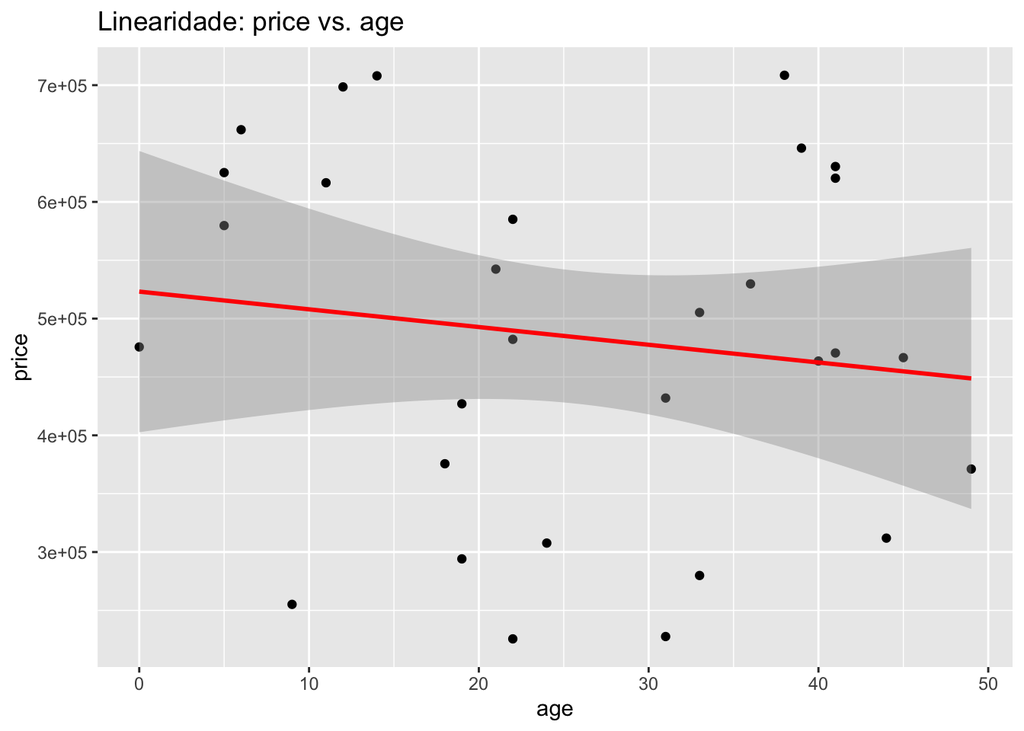

```r
ggplot(dados_habitacao, aes(x = age, y = price)) +
  geom_point() +
  geom_smooth(method = "lm", col = "red") +
  labs(title = "Linearidade: price vs. age")
```

**Homocedasticidade dos resíduos**

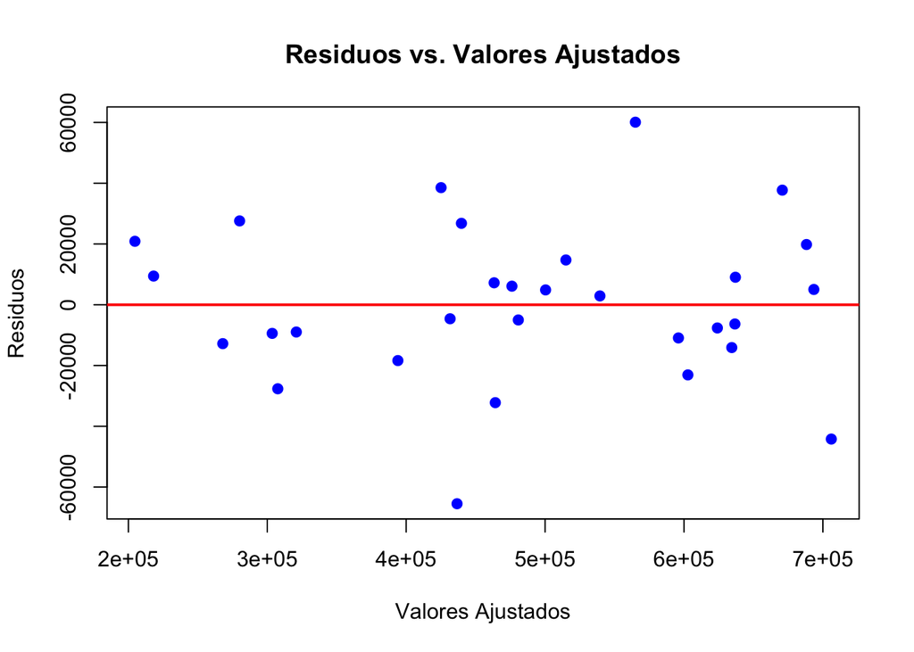

```r
# Plot de resíduos vs. valores ajustados
plot(fitted(modelo_multiplo), residuals(modelo_multiplo),
     main = "Residuos vs. Valores Ajustados",
     xlab = "Valores Ajustados", ylab = "Residuos",
     pch = 19, col = "blue")
abline(h = 0, col = "red", lwd = 2)
```

```r
# Teste de Breusch-Pagan para homocedasticidade
library(lmtest)
bptest(modelo_multiplo)
```

```
    studentized Breusch-Pagan test

data:  modelo_multiplo
BP = 0.46036, df = 3, p-value = 0.9275
```

```r
#Hipótese Nula: Os resíduos são homocedásticos (têm variância constante).
#Hipótese Alternativa:: Os resíduos são heterocedásticos (variância não constante).
#Como o p-value = 0.9275 é muito maior que 0.05, não rejeitamos H0. Isso significa que os resíduos apresentam homocedasticidade → o pressuposto da regressão é válido.
```

**Inexistência de Multicolinearidade**

```r
library(car)
vif(modelo_multiplo)  # Calcula o VIF para cada variável
```

```
    sqft bedrooms      age
1.050871 1.074336 1.023028
```

```r
#Se VIF < 5, não há problema de multicolinearidade.
```

**Normalidade dos resíduos**

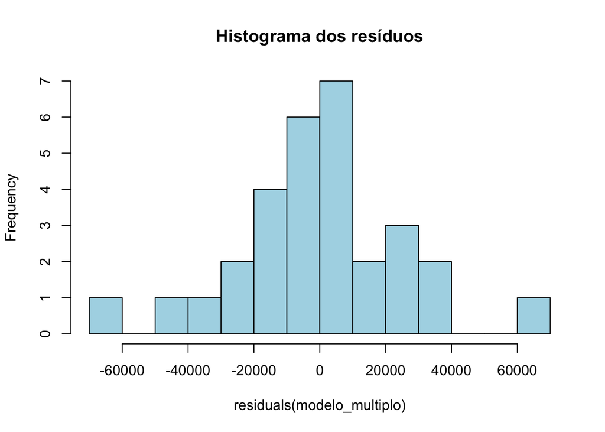

```r
# Histograma dos resíduos
hist(residuals(modelo_multiplo), main = "Histograma dos resíduos", col = "lightblue", breaks = 10)
```

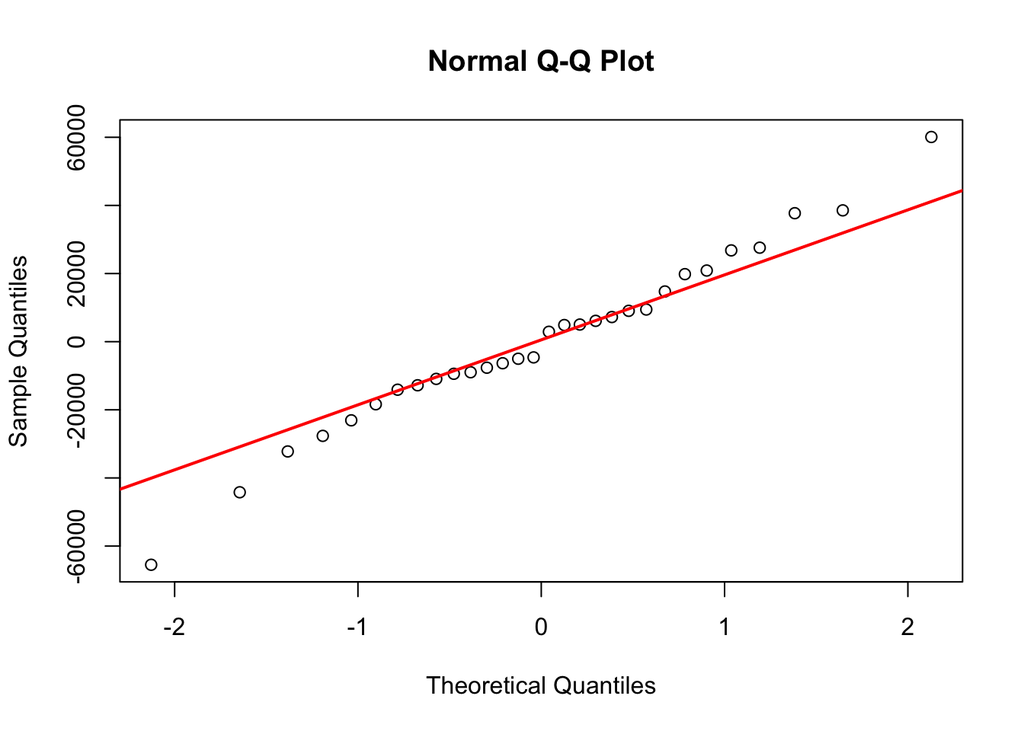

```r
# QQ-Plot dos resíduos
qqnorm(residuals(modelo_multiplo))
qqline(residuals(modelo_multiplo), col = "red", lwd = 2)
```

```r
# Teste de Shapiro-Wilk para normalidade dos resíduos
shapiro.test(residuals(modelo_multiplo))
```

```
    Shapiro-Wilk normality test

data:  residuals(modelo_multiplo)
W = 0.98527, p-value = 0.9417
```

```r
#Se o p-valor do Shapiro-Wilk for > 0.05, os resíduos seguem uma distribuição normal.
```